# ST344 Practical 5

## Regression models for the Spotify data

You will use a part of the same dataset that was used in Lab 3 and the group assignment, i.e., the Spotify data.

You may of course discuss this lab exercise with your fellow students, but the work you submit must be your own.

You are advised to look briefly first at the section at the end below, about this week’s lab report, before launching yourself into the data analysis suggested here.

### Step 1: Load R packages required, and read in the data

(From this point on, at least, **be sure to maintain a record of everything you do**, in a `.Rmd` file. It is sure to help you when preparing the Lab Report.)

```r
library(ggplot2)
```

We will again use the dataset “edited_spotify.xlsx” from Lab 3.

```r
library(readxl)
library(dplyr)
Spotify <- read_excel("edited_spotify.xlsx")
```

### Step 2: Relation between valence and danceability

EDA shows use that there looks to be some association between valence and danceability. This makes some sense, since tracks with a higher valence should sound more positive, and we might expect that these tracks are more suitable for dancing. We will now explore this relationship using regression.

We will fit three different regression models. The first is a standard linear regression. The second is a GLM using a log link function, which is suitable when the response is bounded below by zero. The third is a GLM that uses a beta distribution for modelling a response (suitable for modelling a response between 0 and 1), and using with a logit link function.

```r
# Before we do the regression, we need to make a very small change to the data, since the betareg package doesn't allow a response to be 0.
Spotify$TrackDanceability[which(Spotify$TrackDanceability==0)] = 1e-6

myplot1 <- ggplot(Spotify, aes(x = TrackValence, y = TrackDanceability)) +
    geom_point() +
    geom_smooth(method = 'lm', formula = y ~ x, se = FALSE) +
    ggtitle("Linear regression fit") +
    theme_bw()

myplot2 <- ggplot(Spotify, aes(x = TrackValence, y = TrackDanceability)) +
    geom_point() +
    geom_smooth(method = 'glm', formula = y ~ x, se = FALSE,
                  method.args = list(
                                     family = quasi(link = "log") )) +
    ggtitle("GLM fit with log link") +
    theme_bw()

# We code the final model differently, since the glm command doesn't have the option to use a beta
# distribution for the response.
library(betareg)

gy_logit <- betareg(TrackDanceability ~ TrackValence, data = Spotify)
myplot3 <- ggplot(Spotify, aes(x = TrackValence, y = TrackDanceability)) +
    geom_point() +
    geom_line(aes(y = predict(gy_logit, Spotify)),color=c("#3366FF"),size=1.1) +
    ggtitle("Beta regression fit with logit link") +
    theme_bw()

print(myplot1)
print(myplot2)
print(myplot3)
```

[output not shown]

As explained in Lecture 5, there can be substantial advantages to using GLMs when modelling a bounded continuous response variable. The link function eliminates any possibility of fitted values outside of the bounds, or having computed confidence bands outside of the bounded regions. In our case we might expect the third model to be most appropriate, and it is good practice to use it. However, in this case, the end results of the three regressions are not very different. In this instance a GLM does not buy us very much compared to a standard linear regression, since the data is not really deviating from the assumptions made in the standard linear regression model, and the model we fit is not really affected by the bounds.

## Step 3: How does the valence/danceability relationship differ for music containing speech?

The guide to Spotify audio features at https://developer.spotify.com/documentation/web-api/reference/tracks/get-audio-features/ suggests that rap music or other tracks containing the spoken word are likely to be given a `TrackSpeechiness` rating of above 0.33. Let’s start by examining by eye whether “speechy” tracks look to have a similar valence/danceability relationship.

```r
scatter_plot <- ggplot(Spotify, aes(x = TrackValence, y = TrackDanceability, color=TrackSpeechiness>0.33)) +
      geom_point() +
      ggtitle("") +
      theme_bw()

print(scatter_plot)
```

[output not shown]

Let’s explore the question by using the type of model fitted above as our starting point.

Consider fitting a nested sequence of multiplicative models, with increasing complexity, as follows:

- linear dependence of `TrackDanceability` upon `TrackValence`, as above (i.e., same for speechy and non-speechy tracks)
- a second model in which the linear dependence on valence in the linear predictor is the same for all tracks, but where the intercept is different for speechy and non-speechy tracks
- a third model in which all of the parameters in the linear predictor are different for speech and non-speechy tracks (i.e., there is **interaction** between the effects of `TrackValence` and `TrackSpeechiness` being larger than 0.33).

*Here we go*. Make sure you understand broadly what is being specified here, before trying it out yourself:

```r
model1 <- betareg(TrackDanceability ~ TrackValence, data = Spotify)

model2 <- betareg(TrackDanceability ~ TrackValence + as.numeric(TrackSpeechiness>0.33), data = Spotify)

model3 <- betareg(TrackDanceability ~ -1 + TrackValence + factor(TrackSpeechiness>0.33) + factor(TrackSpeechiness>0.33):TrackValence, data = Spotify)
```

Let’s take a look at what parameters each of those models has:

```r
model1
model2
model3
```

[output not shown]

Note:

- Look at, for example, `summary(model2)` to see the estimated standard error for the parameter of interest there.

```r
summary(model2)
```

[output not shown]

- Or, more generally (and certainly more helpfully for `model3`, since there we want to assess the evidence on several parameters simultaneously) we can analyse this small sequence of models through an analysis of variance table (I used the GLM here, since then I can access the ANOVA table easily).

```r
model1 <- glm(TrackDanceability ~ TrackValence, data = Spotify, family = quasi(link = "log", variance = "mu^2"))

model2 <- glm(TrackDanceability ~ TrackValence + factor(TrackSpeechiness>0.33), data = Spotify, family = quasi(link = "log", variance = "mu^2"))

model3 <- glm(TrackDanceability ~ -1 + TrackValence + factor(TrackSpeechiness>0.33) + factor(TrackSpeechiness>0.33):TrackValence, data = Spotify,  family = quasi(link = "log", variance = "mu^2"))

anova(model1, model2, model3, test="F")
```

[output not shown]

Think about the following:

- From fitting this sequence of models, what do you conclude about how the relationship between valence and danceability differs for speechy and non-speechy tracks?
- Is there anything you might you criticize about the approach taken above?

## Step 4: Visualising the distances between albums

In the final part of the practical, we will have a go at producing a dendrogram to visualise the distance structure in the data, as I presented briefly in lecture 3.

There are a number of different ways of going about this, but for this practical we will focus again solely on the valence, danceability and speechiness variables, this time using the averages of these variables as we did in Practical 3.

```r
library(dplyr)
MyData = {Spotify %>%
    group_by(Artist,AlbumName,AlbumReleaseDate) %>%
    summarize(AlbumValence = mean(TrackValence),
              AlbumDanceability = mean(TrackDanceability),
              AlbumSpeechiness = mean(TrackSpeechiness) )}
```

Before you illustrate the distance structure with a dendrogram, you need to scale the variables you are going to consider. In this case this is not too much of concern, since they are already on the same scale, but we will perform this step anyway so that you can see the syntax. We will also convert the data to a data frame and name the rows using the `Artist` and `AlbumName` variables.

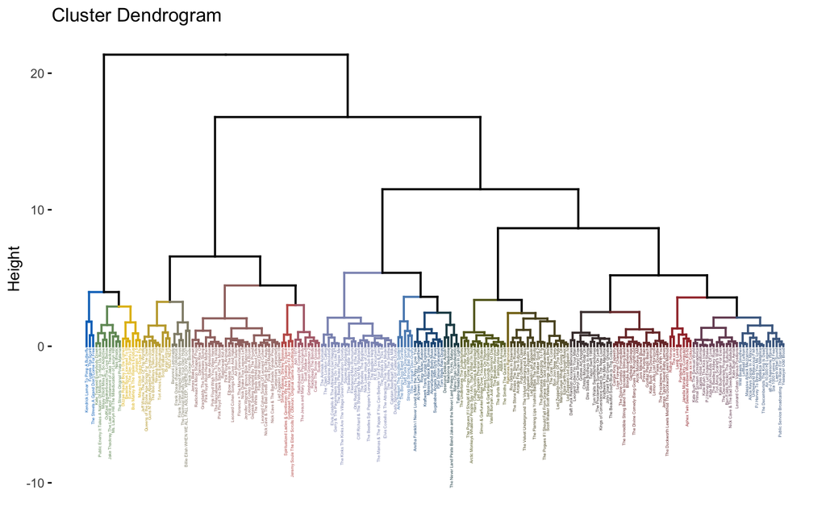

```r
MyDFData = as.data.frame(MyData)
MyDFData[,4:6] <- scale(MyDFData[,4:6])
row.names(MyDFData) = paste(MyDFData$Artist,MyDFData$AlbumName)

res.hc <- hclust(dist(MyDFData[,4:6]),  method = "ward.D2")
library(factoextra)
fviz_dend(res.hc, cex = 0.2, k = 20, palette = "jco", labels_track_height = 10)
```

## Lab report 5

For the fifth (and final) lab report, produce a PDF document (**maximum** length 2 sides of A4, with minimum font size 11pt and minimum margins 2cm all round) that gives your Student ID as author, and submit the PDF file to Moodle.

Your report should give a clear, professional account of the analysis conducted in Step 3 above, and its conclusions.

You should explain the question studied, the data used, and the analysis approach taken.

Your findings should be explained clearly and succinctly, along with a note of any limitations that you might want to mention.

For a fully successful report, you should:

- include enough detail to allow the reader to understand the evidence that is presented (for example, include a clearly presented analysis-of-variance table — but definitely not a copy-paste of the raw *R* output!)
- include a clear, presentable graphical display to illustrate your findings

Deadline for submission on Moodle is Thursday 7 November, 12 noon.